# SLEEP AND LIFESTYLE ANALYSIS

**Importing the dataset**

```r
df<-read.csv("D:/VIT-4/DS/Sleep Analysis Survey (Responses) (2).csv")
head(df)
```

|  | Timestamp | What.is.your.gender. | What.is.your.age. | In.which.year.are.you.currently.studying. | Which.branch.do.you.belong.to. | How.many.hours.of.sleep.do.you.get.on.average. | Rate.your.quality.of.sleep. | How.often.do.you.take.naps.in.a.week..in.days.. | Rate.your.physical.activity.level. | Rate.your.stress.level. | What.is.your.average.number.of.daily.steps. | How.many.hours.do.you.use.electronic.devices.before.sleep. | How.often.do.you.suffer.from.headaches. | How.often.do.you.skip.breakfast. | At.what.time.do.you.eat.your.dinner. | On.an.average..how.many.nights.in.a.week.do.you.go.through.without.sleep. | Your.feedback.about.our.survey. |
| --- | --- | --- | --- | --- | --- | --- | --- | --- | --- | --- | --- | --- | --- | --- | --- | --- | --- |
| 1 | 02-07-2024 10:30 | Male | 18 | SecondYear | Comp | 0 to 5 | 4 | 0 | 9 | 10 | 6k-8k | 1 hour | Rarely | Always | 20:00-21:00 | 3 |  |
| 2 | 02-07-2024 11:04 | Male | 19 | SecondYear | Comp | 7 to 9 | 8 | 0 | 5 | 10 | 6k-8k | 2 hours | Rarely | Never | 21:00-22:00 | 1 |  |
| 3 | 02-07-2024 11:06 | Female | 19 | SecondYear | Comp | 7 to 9 | 6 | 1 to 3 | 5 | 7 | 6k-8k | 2 hours | Never | Always | 19:00-20:00 | 1 | Nice survey |
| 4 | 02-07-2024 11:13 | Female | 19 | SecondYear | Comp | 7 to 9 | 7 | 1 to 3 | 5 | 10 | 4k-6k | 5 hours | Rarely | Never | 21:00-22:00 | 0 | I made it and I am very happy |
| 5 | 02-07-2024 11:15 | Male | 20 | SecondYear | Comp | 5 to 7 | 10 | 0 | 10 | 1 | 0-2k | 1 hour | Never | Rarely | 19:00-20:00 | 0 |  |
| 6 | 02-07-2024 11:38 | Female | 20 | SecondYear | IT | 7 to 9 | 8 | 6 to 7 | 7 | 10 | 4k-6k | 3 hours | Sometimes | Never | 20:00-21:00 | 0 |  |

**Name of the columns**

```r
names(df)
```

```
##  [1] "Timestamp"
##  [2] "What.is.your.gender."
##  [3] "What.is.your.age."
##  [4] "In.which.year.are.you.currently.studying."
##  [5] "Which.branch.do.you.belong.to."
##  [6] "How.many.hours.of.sleep.do.you.get.on.average."
##  [7] "Rate.your.quality.of.sleep."
##  [8] "How.often.do.you.take.naps.in.a.week..in.days.."
##  [9] "Rate.your.physical.activity.level."
## [10] "Rate.your.stress.level."
## [11] "What.is.your.average.number.of.daily.steps."
## [12] "How.many.hours.do.you.use.electronic.devices.before.sleep."
## [13] "How.often.do.you.suffer.from.headaches."
## [14] "How.often.do.you.skip.breakfast."
## [15] "At.what.time.do.you.eat.your.dinner."
## [16] "On.an.average..how.many.nights.in.a.week.do.you.go.through.without.sleep."
## [17] "Your.feedback.about.our.survey."
```

**Changing the column names**

```r
names(df)<-c('Timestamp','Gender','Age','Year','Branch','HoursOfSleep','QualityOfSleep','NapsInAweek', 'PhysicalActivityLevel', 'StressLevel','DailySteps','HoursOfECDevicesBeforeSleep','HeadacheFrequency', 'BreakfastSkip', 'DinnerTime','SleeplessNightsInAWeek','Feedback')
```

**Seeing the modified names**

```r
names(df)
```

```
##  [1] "Timestamp"                   "Gender"
##  [3] "Age"                         "Year"
##  [5] "Branch"                      "HoursOfSleep"
##  [7] "QualityOfSleep"              "NapsInAweek"
##  [9] "PhysicalActivityLevel"       "StressLevel"
## [11] "DailySteps"                  "HoursOfECDevicesBeforeSleep"
## [13] "HeadacheFrequency"           "BreakfastSkip"
## [15] "DinnerTime"                  "SleeplessNightsInAWeek"
## [17] "Feedback"
```

```r
head(df)
```

|  | Timestamp | Gender | Age | Year | Branch | HoursOfSleep | QualityOfSleep | NapsInAweek | PhysicalActivityLevel | StressLevel | DailySteps | HoursOfECDevicesBeforeSleep | HeadacheFrequency | BreakfastSkip | DinnerTime | SleeplessNightsInAWeek | Feedback |
| --- | --- | --- | --- | --- | --- | --- | --- | --- | --- | --- | --- | --- | --- | --- | --- | --- | --- |
| 1 | 02-07-2024 10:30 | Male | 18 | SecondYear | Comp | 0 to 5 | 4 | 0 | 9 | 10 | 6k-8k | 1 hour | Rarely | Always | 20:00-21:00 | 3 |  |
| 2 | 02-07-2024 11:04 | Male | 19 | SecondYear | Comp | 7 to 9 | 8 | 0 | 5 | 10 | 6k-8k | 2 hours | Rarely | Never | 21:00-22:00 | 1 |  |
| 3 | 02-07-2024 11:06 | Female | 19 | SecondYear | Comp | 7 to 9 | 6 | 1 to 3 | 5 | 7 | 6k-8k | 2 hours | Never | Always | 19:00-20:00 | 1 | Nice survey |
| 4 | 02-07-2024 11:13 | Female | 19 | SecondYear | Comp | 7 to 9 | 7 | 1 to 3 | 5 | 10 | 4k-6k | 5 hours | Rarely | Never | 21:00-22:00 | 0 | I made it and I am very happy |
| 5 | 02-07-2024 11:15 | Male | 20 | SecondYear | Comp | 5 to 7 | 10 | 0 | 10 | 1 | 0-2k | 1 hour | Never | Rarely | 19:00-20:00 | 0 |  |
| 6 | 02-07-2024 11:38 | Female | 20 | SecondYear | IT | 7 to 9 | 8 | 6 to 7 | 7 | 10 | 4k-6k | 3 hours | Sometimes | Never | 20:00-21:00 | 0 |  |

**Removing timestamp and feedback from dataframe.**

```r
df <- df[, !(names(df) %in% c("Timestamp", "Feedback"))]
```

```r
head(df)
```

|  | Gender | Age | Year | Branch | HoursOfSleep | QualityOfSleep | NapsInAweek | PhysicalActivityLevel | StressLevel | DailySteps | HoursOfECDevicesBeforeSleep | HeadacheFrequency | BreakfastSkip | DinnerTime | SleeplessNightsInAWeek |
| --- | --- | --- | --- | --- | --- | --- | --- | --- | --- | --- | --- | --- | --- | --- | --- |
| 1 | Male | 18 | SecondYear | Comp | 0 to 5 | 4 | 0 | 9 | 10 | 6k-8k | 1 hour | Rarely | Always | 20:00-21:00 | 3 |
| 2 | Male | 19 | SecondYear | Comp | 7 to 9 | 8 | 0 | 5 | 10 | 6k-8k | 2 hours | Rarely | Never | 21:00-22:00 | 1 |
| 3 | Female | 19 | SecondYear | Comp | 7 to 9 | 6 | 1 to 3 | 5 | 7 | 6k-8k | 2 hours | Never | Always | 19:00-20:00 | 1 |
| 4 | Female | 19 | SecondYear | Comp | 7 to 9 | 7 | 1 to 3 | 5 | 10 | 4k-6k | 5 hours | Rarely | Never | 21:00-22:00 | 0 |
| 5 | Male | 20 | SecondYear | Comp | 5 to 7 | 10 | 0 | 10 | 1 | 0-2k | 1 hour | Never | Rarely | 19:00-20:00 | 0 |
| 6 | Female | 20 | SecondYear | IT | 7 to 9 | 8 | 6 to 7 | 7 | 10 | 4k-6k | 3 hours | Sometimes | Never | 20:00-21:00 | 0 |

**Count of male and female in gender column**

```r
count1 <- table(df$Gender, df$SleeplessNightsInAWeek)
count1
```

```
##
##            0   1   2   3   4   5   6   7
##   Female  72  24  14   3   2   3   0   3
##   Male   225  75  32   9   6   4   3   8
```

**Distribution of Gender**

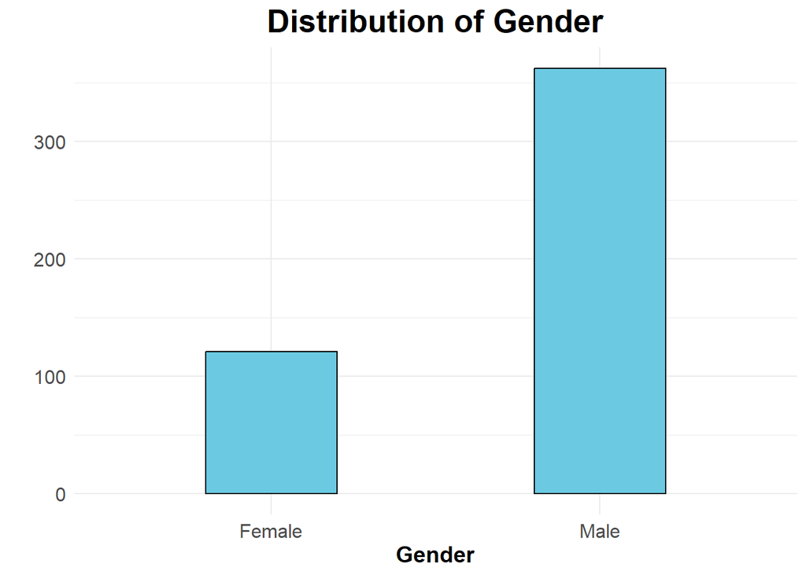

```r
library("ggplot2")

ggplot(df, aes(x = Gender, fill = SleeplessNightsInAWeek)) +
  geom_bar(color = "black", fill = "#6BCAE2", width = 0.4) +
  labs(title = "Distribution of Gender", x = "Gender", y = "") +
  theme_minimal()+theme(
    plot.title = element_text(size = 20, face = "bold", hjust = 0.5),
    axis.title.x = element_text(size = 14, face = "bold"),
    axis.title.y = element_text(size = 14, face = "bold"),
    axis.text = element_text(size = 12)
  )
```

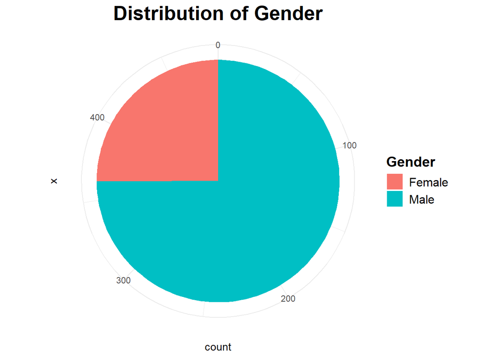

```r
library(ggplot2)

ggplot(df, aes(x = "", fill = Gender)) +
  geom_bar(width = 1) +
  coord_polar("y") +
  labs(title = "Distribution of Gender", fill = "Gender") +
  theme_minimal() +
  theme(
    plot.title = element_text(size = 20, face = "bold", hjust = 0.5),
    legend.title = element_text(size = 14, face = "bold"),
    legend.text = element_text(size = 12)
  )
```

**Count of various ages in age column**

```r
count2 <- table(df$Age, df$SleeplessNightsInAWeek)
count2
```

```
##
##       0  1  2  3  4  5  6  7
##   17  3  0  0  0  0  0  0  0
##   18 42 19  3  3  1  1  1  1
##   19 99 33 16  4  5  1  0  3
##   20 89 33 20  2  2  1  2  3
##   21 49 11  3  2  0  1  0  1
##   22  9  2  3  1  0  2  0  1
##   23  4  0  1  0  0  1  0  1
##   24  2  1  0  0  0  0  0  1
```

**Distribution of Ages**

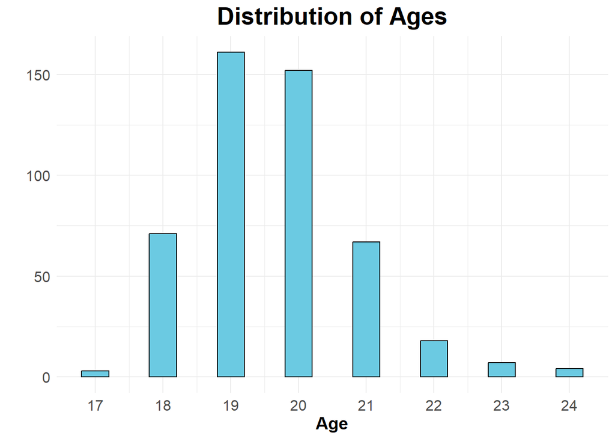

```r
ggplot(df, aes(x = Age, fill = SleeplessNightsInAWeek)) +
  geom_bar(color = "black", fill = "#6BCAE2", width = 0.4) +
  labs(title = "Distribution of Ages", x = "Age", y = "") +
  theme_minimal()+theme(
    plot.title = element_text(size = 20, face = "bold", hjust = 0.5),
    axis.title.x = element_text(size = 14, face = "bold"),
    axis.title.y = element_text(size = 14, face = "bold"),
    axis.text = element_text(size = 12)
  )+scale_x_continuous(breaks = unique(df$Age))
```

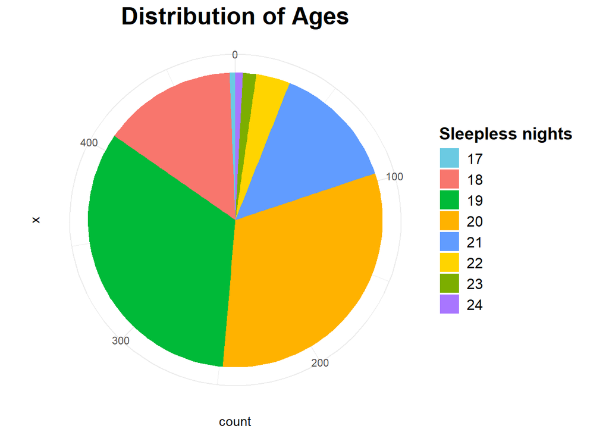

```r
ggplot(df, aes(x = "", fill = factor(Age))) +
  geom_bar(width = 1) +
  coord_polar("y") +
  labs(title = "Distribution of Ages", fill = "Sleepless nights") +
  theme_minimal() +
  theme(
    plot.title = element_text(size = 20, face = "bold", hjust = 0.5),
    legend.title = element_text(size = 14, face = "bold"),
    legend.text = element_text(size = 12)
  ) +
  scale_fill_manual(values = c("#6BCAE2", "#F8766D", "#00BA38", "#FFB200", "#619CFF", "#FFD400", "#7CAE00", "#A876FF"))
```

**Count of First Year, Second Year, Third Year and BTech**

```r
count3 <- table(df$Year, df$SleeplessNightsInAWeek)
count3
```

```
##
##                0   1   2   3   4   5   6   7
##   BTech       19   3   3   0   0   1   0   0
##   FirstYear   73  27  11   1   3   1   1   4
##   SecondYear 132  52  16   7   4   3   1   4
##   ThirdYear   73  17  16   4   1   2   1   3
```

**Distribution of Engineering Years**

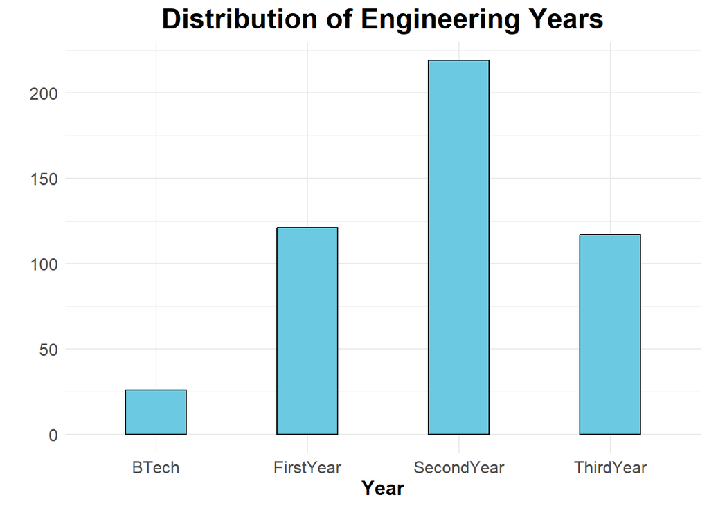

```r
ggplot(df, aes(x = Year, fill = SleeplessNightsInAWeek)) +
  geom_bar(color = "black", fill = "#6BCAE2", width = 0.4) +
  labs(title = "Distribution of Engineering Years", x = "Year", y = "") +
  theme_minimal()+theme(
    plot.title = element_text(size = 20, face = "bold", hjust = 0.5),
    axis.title.x = element_text(size = 14, face = "bold"),
    axis.title.y = element_text(size = 14, face = "bold"),
    axis.text = element_text(size = 12)
  )
```

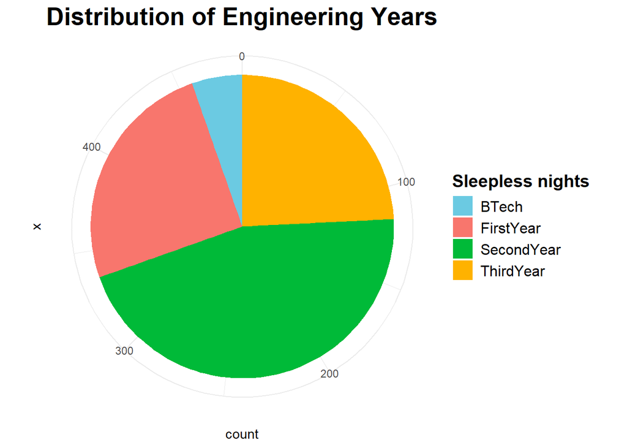

```r
ggplot(df, aes(x = "", fill = factor(Year))) +
  geom_bar(width = 1) +
  coord_polar("y") +
  labs(title = "Distribution of Engineering Years", fill = "Sleepless nights") +
  theme_minimal() +
  theme(
    plot.title = element_text(size = 20, face = "bold", hjust = 0.5),
    legend.title = element_text(size = 14, face = "bold"),
    legend.text = element_text(size = 12)
  ) +
  scale_fill_manual(values = c("#6BCAE2", "#F8766D", "#00BA38", "#FFB200"))
```

**Count of CS-AIML, Chem & IC, Comp, ENTC, IT, and Mech.**

```r
count4 <- table(df$Branch, df$SleeplessNightsInAWeek)
count4
```

```
##
##           0  1  2  3  4  5  6  7
##   AIML   82 25  6  1  2  2  1  3
##   ChemIC 29  6 10  3  0  1  1  1
##   Comp   63 24 12  3  0  1  0  2
##   ET     37 16  6  3  3  2  1  1
##   IT     36 17  5  1  3  1  0  1
##   Mech   50 11  7  1  0  0  0  3
```

**Distribution of Branches**

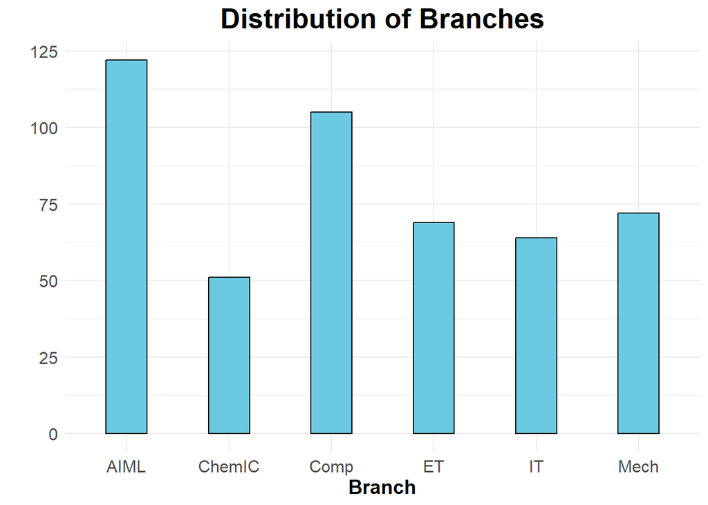

```r
ggplot(df, aes(x = Branch, fill = SleeplessNightsInAWeek)) +
  geom_bar(color = "black", fill = "#6BCAE2", width = 0.4) +
  labs(title = "Distribution of Branches", x = "Branch", y = "") +
  theme_minimal()+theme(
    plot.title = element_text(size = 20, face = "bold", hjust = 0.5),
    axis.title.x = element_text(size = 14, face = "bold"),
    axis.title.y = element_text(size = 14, face = "bold"),
    axis.text = element_text(size = 12)
  )
```

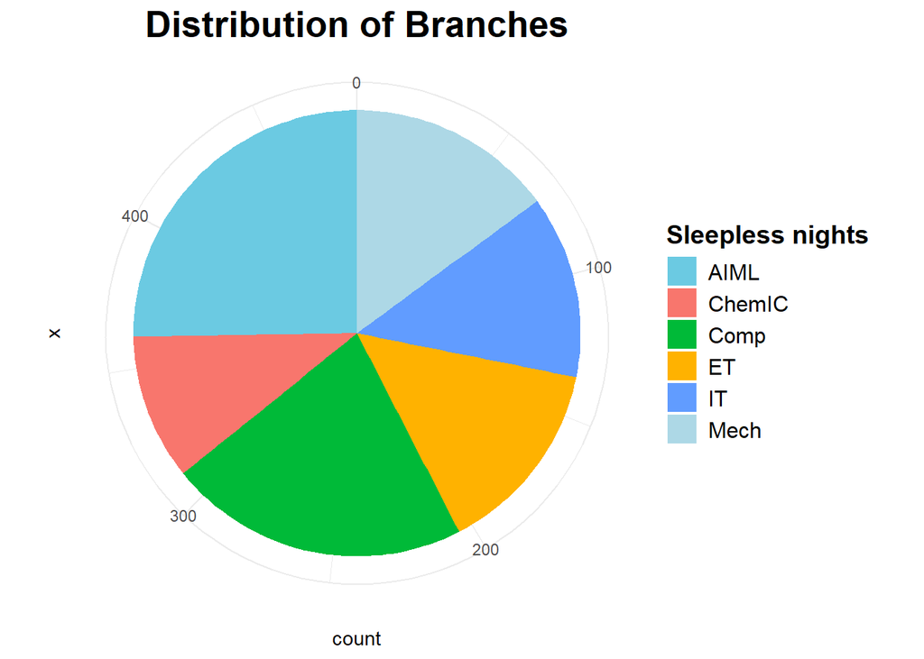

```r
ggplot(df, aes(x = "", fill = factor(Branch))) +
  geom_bar(width = 1) +
  coord_polar("y") +
  labs(title = "Distribution of Branches", fill = "Sleepless nights") +
  theme_minimal() +
  theme(
    plot.title = element_text(size = 20, face = "bold", hjust = 0.5),
    legend.title = element_text(size = 14, face = "bold"),
    legend.text = element_text(size = 12)
  ) +
  scale_fill_manual(values = c("#6BCAE2", "#F8766D", "#00BA38", "#FFB200", "#619CFF","#ADD8E6"))
```

**Count of Unique Values in Hours of Sleep Column**

```r
count5 <- table(df$HoursOfSleep, df$SleeplessNightsInAWeek)
count5
```

```
##
##            0   1   2   3   4   5   6   7
##   0 to 5  17  15   7   6   2   1   1   7
##   5 to 7 153  62  25   6   5   5   0   1
##   7 to 9 117  20  12   0   1   0   2   0
##   9       10   2   2   0   0   1   0   3
```

**Distribution of Hours of Sleep**

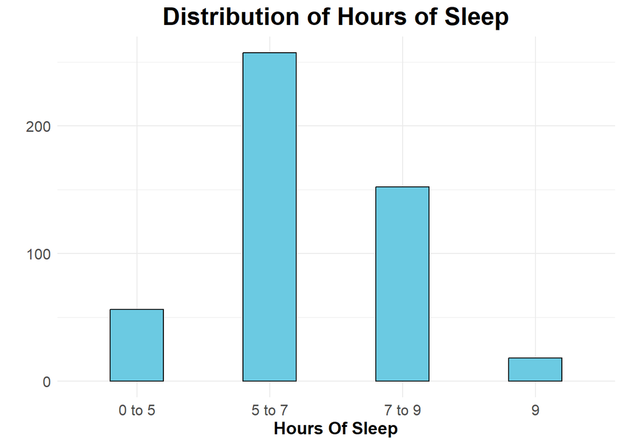

```r
ggplot(df, aes(x = HoursOfSleep, fill = SleeplessNightsInAWeek)) +
  geom_bar(color = "black", fill = "#6BCAE2", width = 0.4) +
  labs(title = "Distribution of Hours of Sleep", x = "Hours Of Sleep", y = "") +
  theme_minimal()+theme(
    plot.title = element_text(size = 20, face = "bold", hjust = 0.5),
    axis.title.x = element_text(size = 14, face = "bold"),
    axis.title.y = element_text(size = 14, face = "bold"),
    axis.text = element_text(size = 12)
  )
```

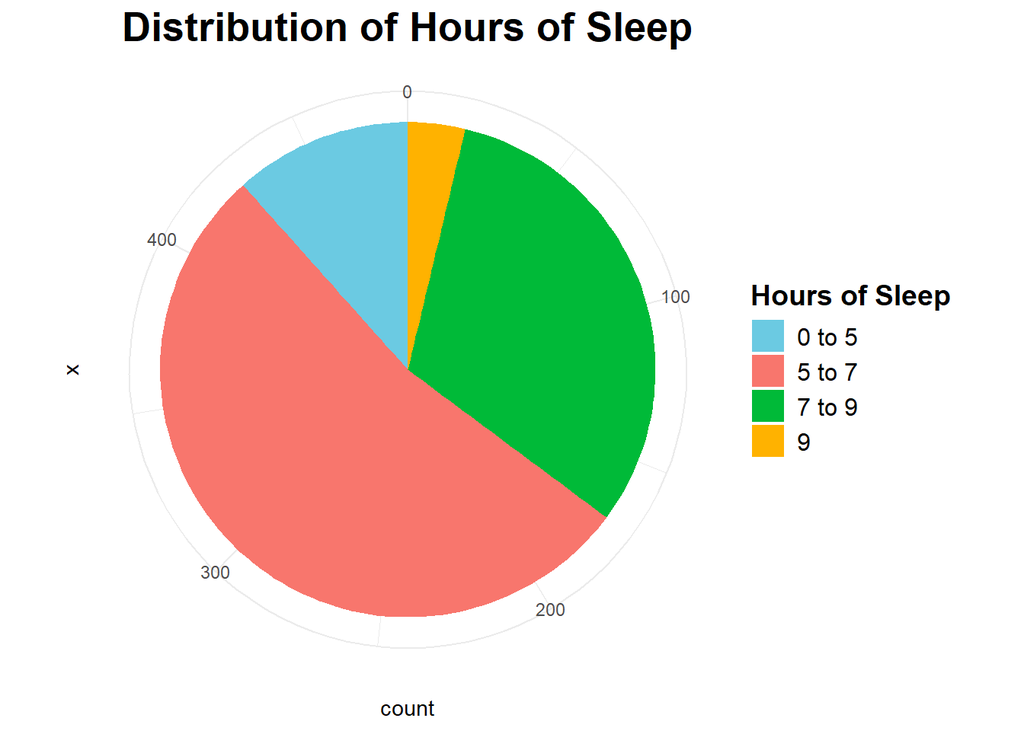

```r
ggplot(df, aes(x = "", fill = factor(HoursOfSleep))) +
  geom_bar(width = 1) +
  coord_polar("y") +
  labs(title = "Distribution of Hours of Sleep", fill = "Hours of Sleep")+
  theme_minimal() +
  theme(
    plot.title = element_text(size = 20, face = "bold", hjust = 0.5),
    legend.title = element_text(size = 14, face = "bold"),
    legend.text = element_text(size = 12)
  ) +
  scale_fill_manual(values = c("#6BCAE2", "#F8766D", "#00BA38", "#FFB200"))
```

**Count of Unique Values in Quality Of Sleep Column**

```r
count6 <- table(df$QualityOfSleep, df$SleeplessNightsInAWeek)
count6
```

```
##
##       0  1  2  3  4  5  6  7
##   1   4  3  2  0  1  2  1  6
##   2   0  0  0  1  1  1  1  0
##   3   4  9  5  2  3  2  0  1
##   4  13 12  5  5  0  0  0  0
##   5  27  9  7  1  2  1  0  1
##   6  30 15 10  1  0  1  0  0
##   7  58 23 10  1  1  0  0  0
##   8  81 17  7  0  0  0  1  1
##   9  52  5  0  0  0  0  0  0
##   10 28  6  0  1  0  0  0  2
```

**Distribution of Quality Of Sleep**

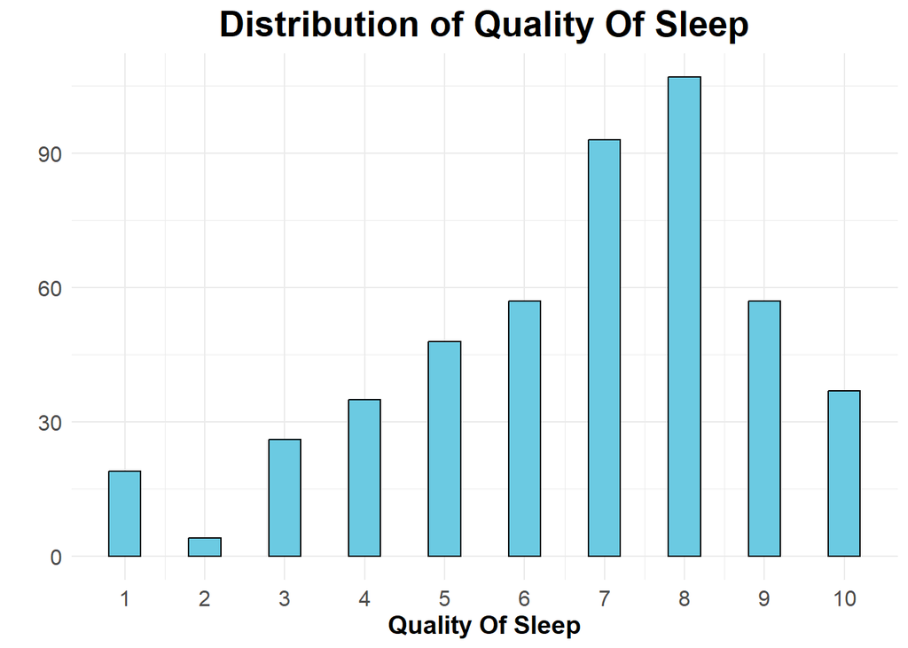

```r
ggplot(df, aes(x = QualityOfSleep, fill = SleeplessNightsInAWeek)) +
  geom_bar(color = "black", fill = "#6BCAE2", width = 0.4) +
  labs(title = "Distribution of Quality Of Sleep", x = "Quality Of Sleep", y = "") +
  theme_minimal()+theme(
    plot.title = element_text(size = 20, face = "bold", hjust = 0.5),
    axis.title.x = element_text(size = 14, face = "bold"),
    axis.title.y = element_text(size = 14, face = "bold"),
    axis.text = element_text(size = 12)
  )+scale_x_continuous(breaks = unique(df$QualityOfSleep))
```

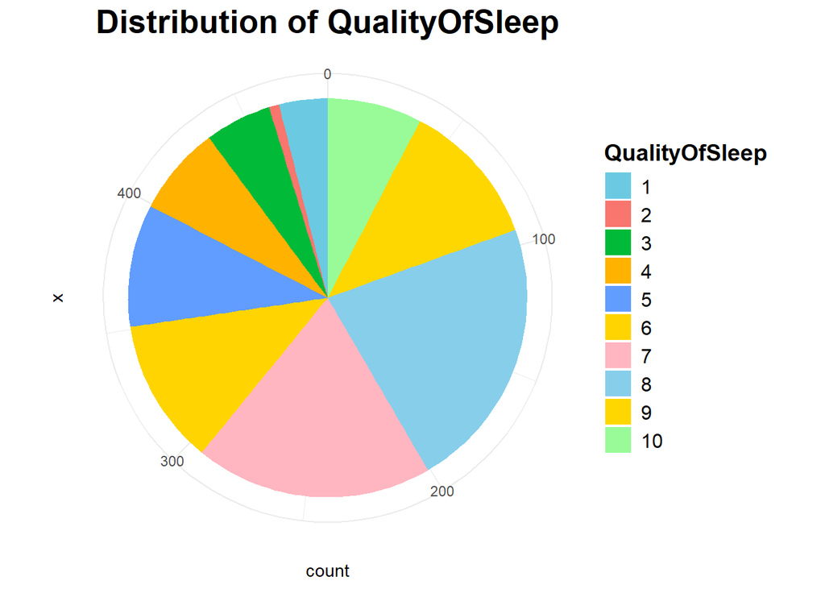

```r
ggplot(df, aes(x = "", fill = factor(QualityOfSleep))) +
  geom_bar(width = 1) +
  coord_polar("y") +
  labs(title = "Distribution of QualityOfSleep", fill = "QualityOfSleep")+
  theme_minimal() +
  theme(
    plot.title = element_text(size = 20, face = "bold", hjust = 0.5),
    legend.title = element_text(size = 14, face = "bold"),
    legend.text = element_text(size = 12)
  ) +
  scale_fill_manual(values = c("#6BCAE2", "#F8766D", "#00BA38", "#FFB200","#619CFF","#FFD400","#FFB6C1","#87CEEB","#FFD700","#98FB98"))
```

**Count of Unique Values in Nap Frequency Column**

```r
count7 <- table(df$NapsInAweek, df$SleeplessNightsInAWeek)
count7
```

```
##
##            0   1   2   3   4   5   6   7
##   0       90  27  12   3   2   2   1   7
##   1 to 3 145  48  24   7   1   1   2   1
##   4 to 5  39  12   8   2   4   1   0   2
##   6 to 7  23  12   2   0   1   3   0   1
```

**Distribution of Naps In A Week**

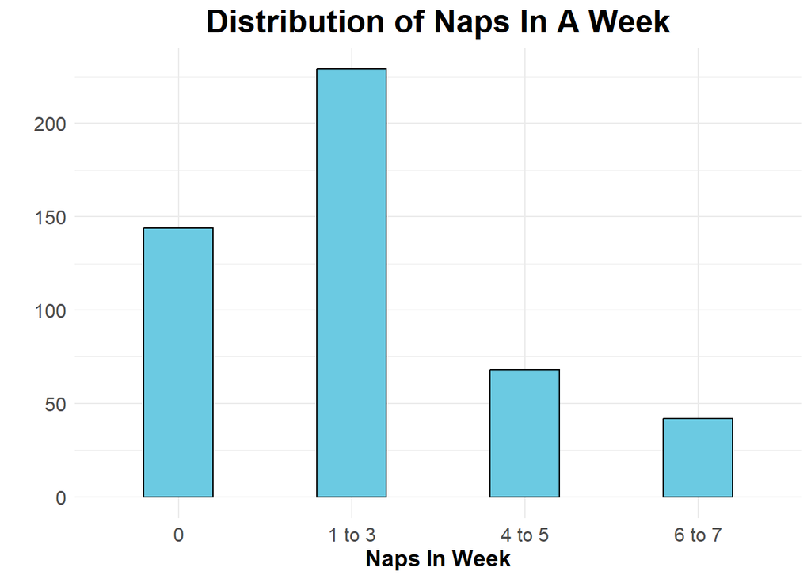

```r
ggplot(df, aes(x = NapsInAweek, fill = SleeplessNightsInAWeek)) +
  geom_bar(color = "black", fill = "#6BCAE2", width = 0.4) +
  labs(title = "Distribution of Naps In A Week", x = "Naps In Week", y = "") +
  theme_minimal()+theme(
    plot.title = element_text(size = 20, face = "bold", hjust = 0.5),
    axis.title.x = element_text(size = 14, face = "bold"),
    axis.title.y = element_text(size = 14, face = "bold"),
    axis.text = element_text(size = 12)
  )
```

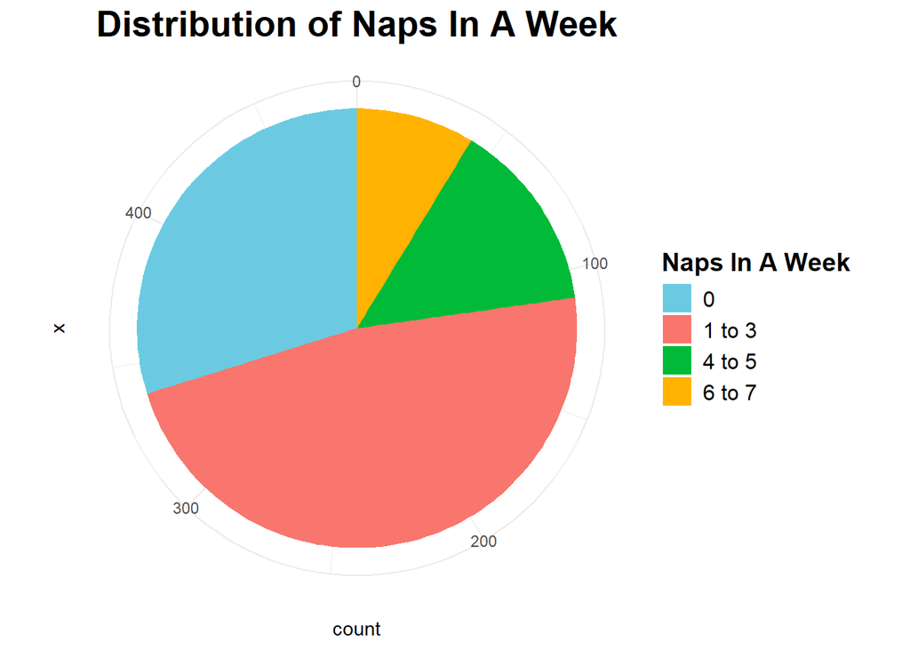

```r
ggplot(df, aes(x = "", fill = factor(NapsInAweek))) +
  geom_bar(width = 1) +
  coord_polar("y") +
  labs(title = "Distribution of Naps In A Week", fill = "Naps In A Week")+
  theme_minimal() +
  theme(
    plot.title = element_text(size = 20, face = "bold", hjust = 0.5),
    legend.title = element_text(size = 14, face = "bold"),
    legend.text = element_text(size = 12)
  ) +
  scale_fill_manual(values = c("#6BCAE2", "#F8766D", "#00BA38", "#FFB200"))
```

**Count of Unique Values in Physical Activity Column**

```r
count8 <- table(df$PhysicalActivityLevel, df$SleeplessNightsInAWeek)
count8
```

```
##
##       0  1  2  3  4  5  6  7
##   1  12  2  1  1  0  1  0  5
##   2  10  3  3  1  1  0  0  0
##   3  25  5  5  2  2  1  0  1
##   4  22 13  6  2  2  1  0  0
##   5  33 12  6  2  1  2  1  1
##   6  33 18  5  2  0  2  0  1
##   7  55 19  7  0  1  0  0  0
##   8  54 17  8  1  1  0  2  0
##   9  33  5  2  1  0  0  0  0
##   10 20  5  3  0  0  0  0  3
```

**Distribution of Physical Activity Level**

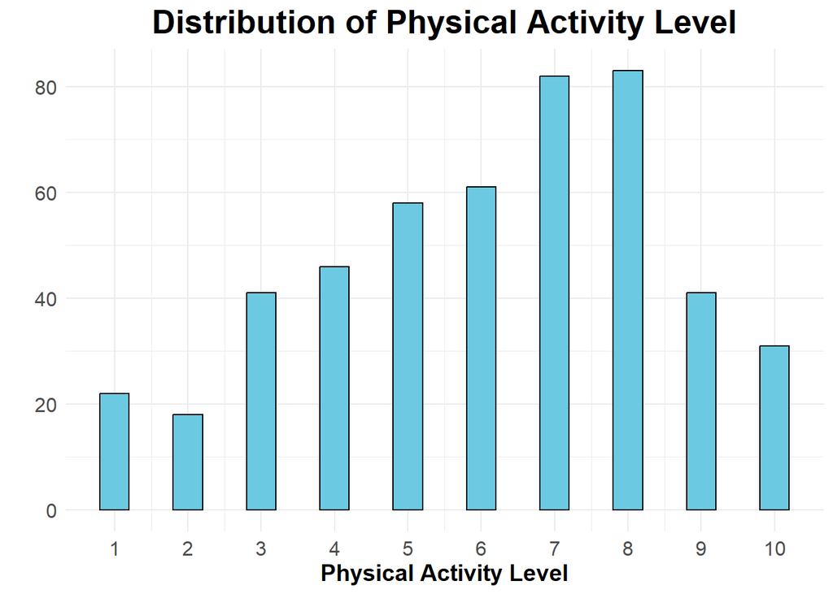

```r
ggplot(df, aes(x = PhysicalActivityLevel, fill = SleeplessNightsInAWeek)) +
  geom_bar(color = "black", fill = "#6BCAE2", width = 0.4) +
  labs(title = "Distribution of Physical Activity Level", x = "Physical Activity Level", y = "") +
  theme_minimal()+theme(
    plot.title = element_text(size = 20, face = "bold", hjust = 0.5),
    axis.title.x = element_text(size = 14, face = "bold"),
    axis.title.y = element_text(size = 14, face = "bold"),
    axis.text = element_text(size = 12)
  )+ scale_x_continuous(breaks = unique(df$PhysicalActivityLevel))
```

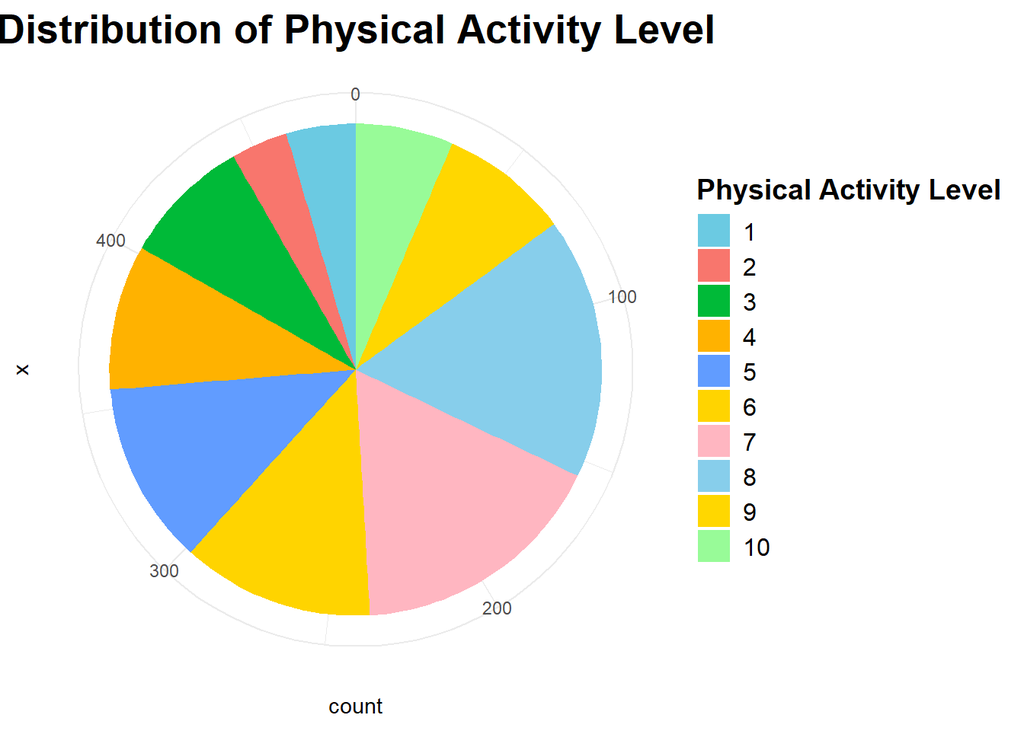

```r
ggplot(df, aes(x = "", fill = factor(PhysicalActivityLevel))) +
  geom_bar(width = 1) +
  coord_polar("y") +
  labs(title = "Distribution of Physical Activity Level", fill = "Physical Activity Level")+
  theme_minimal() +
  theme(
    plot.title = element_text(size = 20, face = "bold", hjust = 0.5),
    legend.title = element_text(size = 14, face = "bold"),
    legend.text = element_text(size = 12)
  ) +
  scale_fill_manual(values = c("#6BCAE2", "#F8766D", "#00BA38", "#FFB200","#619CFF","#FFD400","#FFB6C1","#87CEEB","#FFD700","#98FB98"))
```

```r
count9 <- table(df$StressLevel, df$SleeplessNightsInAWeek)
count9
```

```
##
##       0  1  2  3  4  5  6  7
##   1  17  0  2  0  0  0  1  2
##   2  14  2  1  0  1  0  0  0
##   3  29  5  1  0  1  1  0  1
##   4  22 12  3  0  0  0  0  0
##   5  51 15  3  2  1  0  1  0
##   6  27  6 11  1  0  2  0  0
##   7  41 12 11  1  1  1  0  0
##   8  48 17  6  1  0  0  0  0
##   9  24 17  3  2  1  0  0  0
##   10 24 13  5  5  3  3  1  8
```

**Distribution of Stress Level**

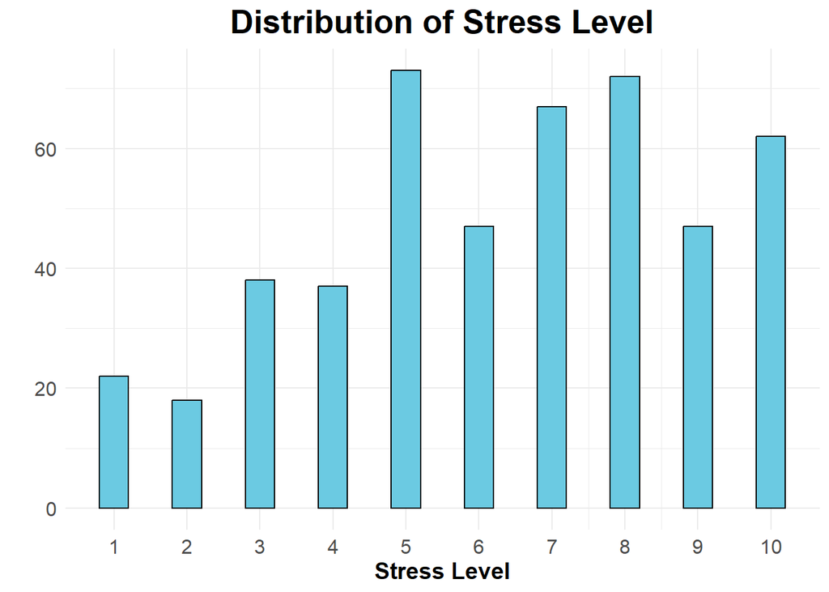

```r
ggplot(df, aes(x = StressLevel, fill = SleeplessNightsInAWeek)) +
  geom_bar(color = "black", fill = "#6BCAE2", width = 0.4) +
  labs(title = "Distribution of Stress Level", x = "Stress Level", y = "") +
  theme_minimal()+theme(
    plot.title = element_text(size = 20, face = "bold", hjust = 0.5),
    axis.title.x = element_text(size = 14, face = "bold"),
    axis.title.y = element_text(size = 14, face = "bold"),
    axis.text = element_text(size = 12)
  )+ scale_x_continuous(breaks = unique(df$StressLevel))
```

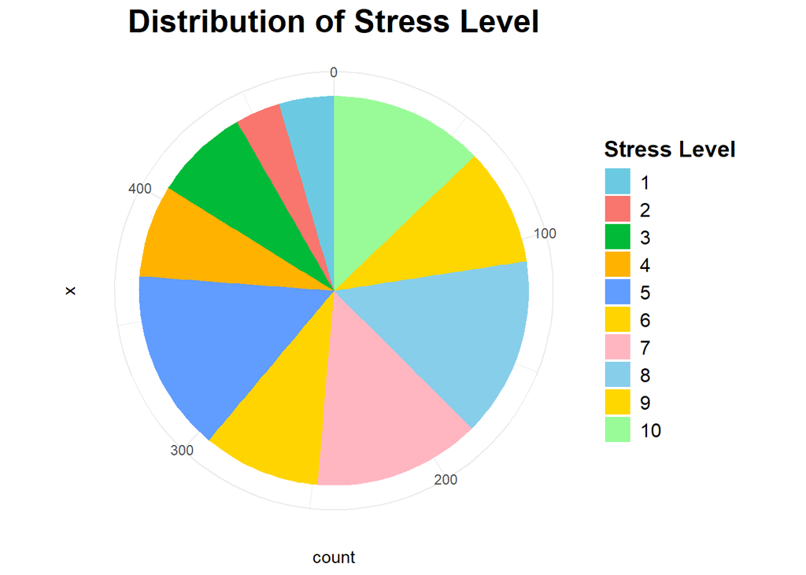

```r
ggplot(df, aes(x = "", fill = factor(StressLevel))) +
  geom_bar(width = 1) +
  coord_polar("y") +
  labs(title = "Distribution of Stress Level", fill = "Stress Level")+
  theme_minimal() +
  theme(
    plot.title = element_text(size = 20, face = "bold", hjust = 0.5),
    legend.title = element_text(size = 14, face = "bold"),
    legend.text = element_text(size = 12)
  ) +
  scale_fill_manual(values = c("#6BCAE2", "#F8766D", "#00BA38", "#FFB200","#619CFF","#FFD400","#FFB6C1","#87CEEB","#FFD700","#98FB98"))
```

**Count of Unique Values in Daily Steps Column**

```r
count10 <- table(df$DailySteps, df$SleeplessNightsInAWeek)
count10
```

```
##
##                 0  1  2  3  4  5  6  7
##   0-2k         38 10  6  0  1  1  1  5
##   2k-4k        55 21  5  1  0  2  0  0
##   4k-6k        81 25  9  4  1  2  0  0
##   6k-8k        74 26 13  4  2  2  1  0
##   8k-10k       25 10 10  3  1  0  0  0
##   Grt than 10k 24  7  3  0  3  0  1  6
```

**Distribution of Daily Steps**

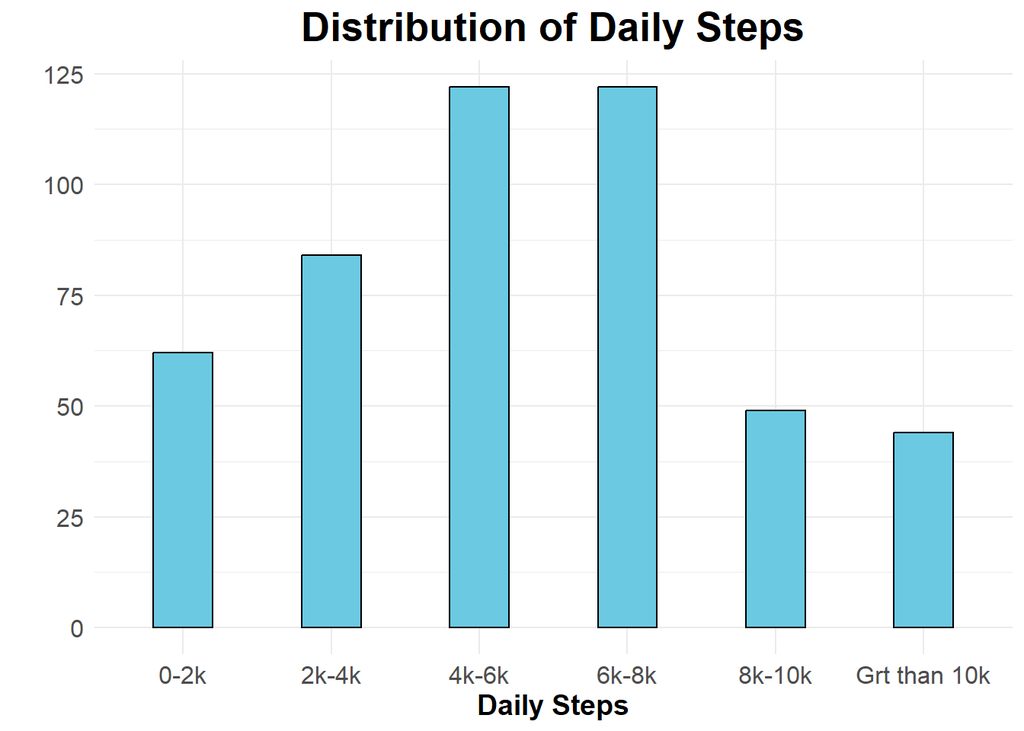

```r
ggplot(df, aes(x = DailySteps, fill = SleeplessNightsInAWeek)) +
  geom_bar(color = "black", fill = "#6BCAE2", width = 0.4) +
  labs(title = "Distribution of Daily Steps", x = "Daily Steps", y = "") +
  theme_minimal()+theme(
    plot.title = element_text(size = 20, face = "bold", hjust = 0.5),
    axis.title.x = element_text(size = 14, face = "bold"),
    axis.title.y = element_text(size = 14, face = "bold"),
    axis.text = element_text(size = 12)
  )
```

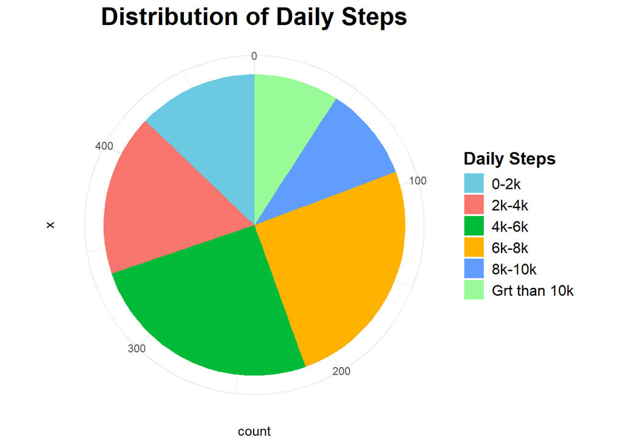

```r
ggplot(df, aes(x = "", fill = factor(DailySteps))) +
  geom_bar(width = 1) +
  coord_polar("y") +
  labs(title = "Distribution of Daily Steps", fill = "Daily Steps")+
  theme_minimal() +
  theme(
    plot.title = element_text(size = 20, face = "bold", hjust = 0.5),
    legend.title = element_text(size = 14, face = "bold"),
    legend.text = element_text(size = 12)
  ) +
  scale_fill_manual(values = c("#6BCAE2", "#F8766D", "#00BA38", "#FFB200","#619CFF","#98FB98"))  # Adjust colors if needed
```

**Count of Unique Values in Hours of EC devices Column**

```r
count11 <- table(df$HoursOfECDevicesBeforeSleep, df$SleeplessNightsInAWeek)
count11
```

```
##
##             0   1   2   3   4   5   6   7
##   1 hour  111  28  10   3   1   2   1   2
##   2 hours  61  29   6   0   0   0   0   0
##   3 hours  57  14  11   3   2   3   1   0
##   4 hours  28  11   6   1   3   1   0   0
##   5 hours  40  17  13   5   2   1   1   9
```

**Distribution of Hours of EC Devices**

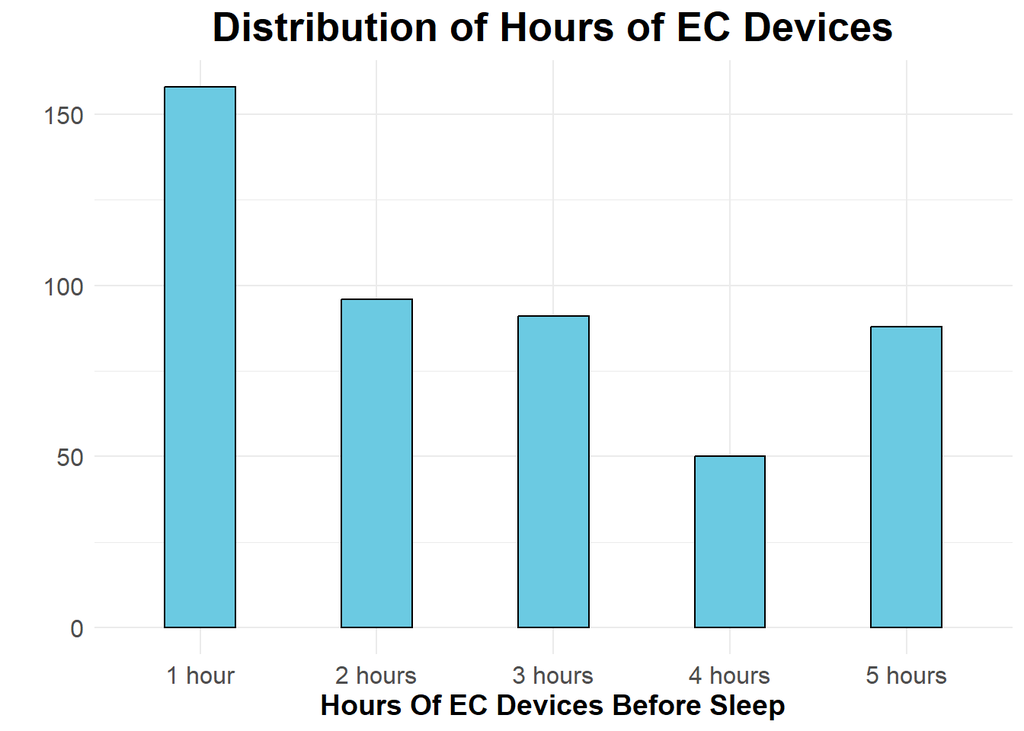

```r
ggplot(df, aes(x = HoursOfECDevicesBeforeSleep, fill = SleeplessNightsInAWeek)) +
  geom_bar(color = "black", fill = "#6BCAE2", width = 0.4) +
  labs(title = "Distribution of Hours of EC Devices", x = "Hours Of EC Devices Before Sleep", y = "") +
  theme_minimal()+theme(
    plot.title = element_text(size = 20, face = "bold", hjust = 0.5),
    axis.title.x = element_text(size = 14, face = "bold"),
    axis.title.y = element_text(size = 14, face = "bold"),
    axis.text = element_text(size = 12)
  )
```

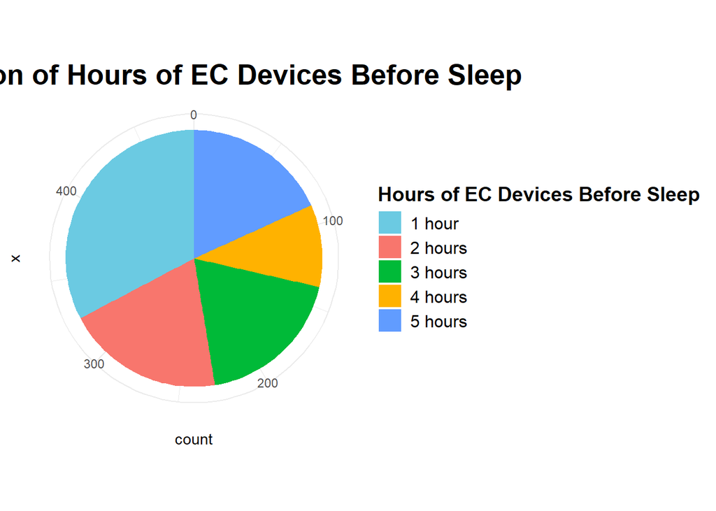

```r
ggplot(df, aes(x = "", fill = factor(HoursOfECDevicesBeforeSleep))) +
  geom_bar(width = 1) +
  coord_polar("y") +
  labs(title = "Distribution of Hours of EC Devices Before Sleep", fill = "Hours of EC Devices Before Sleep")+
  theme_minimal() +
  theme(
    plot.title = element_text(size = 20, face = "bold", hjust = 0.5),
    legend.title = element_text(size = 14, face = "bold"),
    legend.text = element_text(size = 12)
  ) +
  scale_fill_manual(values = c("#6BCAE2", "#F8766D", "#00BA38", "#FFB200","#619CFF"))
```

**Count of Unique Values in Headache Frequency Column**

```r
count12 <- table(df$HeadacheFrequency, df$SleeplessNightsInAWeek)
count12
```

```
##
##               0   1   2   3   4   5   6   7
##   Always      9   3   3   2   2   1   0   7
##   Never      38   5   3   0   1   1   0   2
##   Often      37  10  10   4   1   1   1   0
##   Rarely    130  38  11   5   2   3   1   1
##   Sometimes  83  43  19   1   2   1   1   1
```

**Distribution of Headache Frequency**

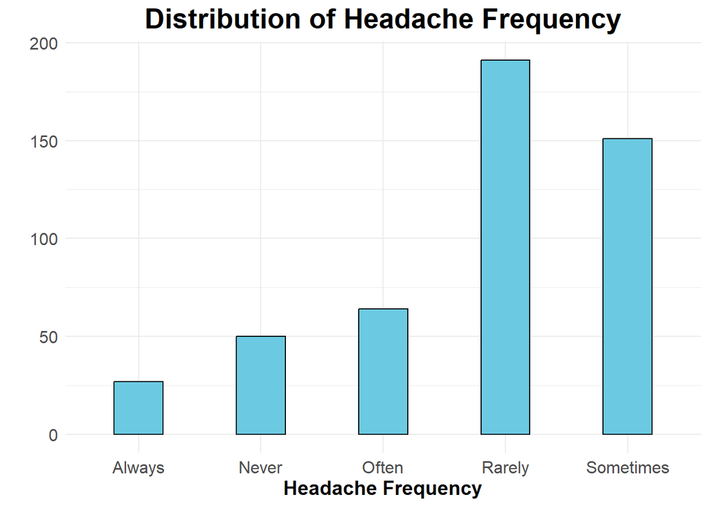

```r
ggplot(df, aes(x = HeadacheFrequency, fill = SleeplessNightsInAWeek)) +
  geom_bar(color = "black", fill = "#6BCAE2", width = 0.4) +
  labs(title = "Distribution of Headache Frequency", x = "Headache Frequency", y = "") +
  theme_minimal()+theme(
    plot.title = element_text(size = 20, face = "bold", hjust = 0.5),
    axis.title.x = element_text(size = 14, face = "bold"),
    axis.title.y = element_text(size = 14, face = "bold"),
    axis.text = element_text(size = 12)
  )
```

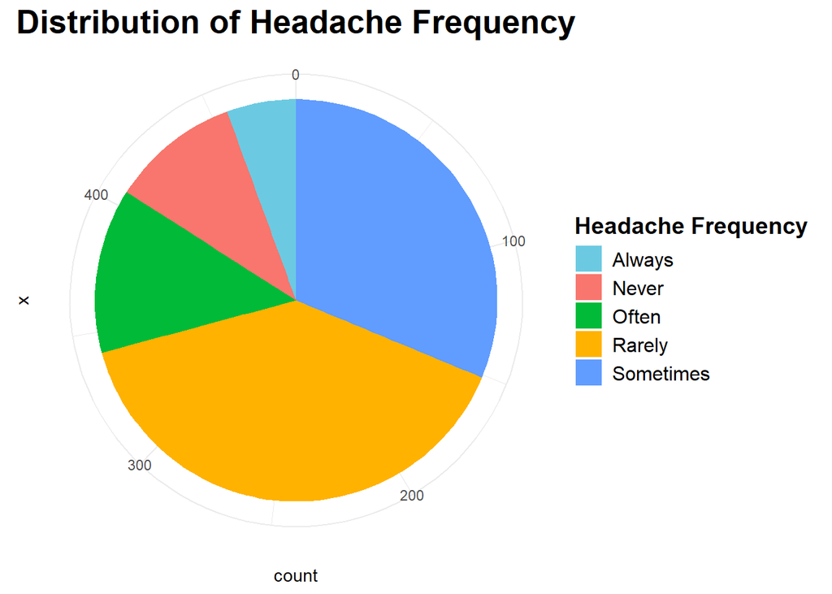

```r
ggplot(df, aes(x = "", fill = factor(HeadacheFrequency))) +
  geom_bar(width = 1) +
  coord_polar("y") +
  labs(title = "Distribution of Headache Frequency", fill = "Headache Frequency")+
  theme_minimal() +
  theme(
    plot.title = element_text(size = 20, face = "bold", hjust = 0.5),
    legend.title = element_text(size = 14, face = "bold"),
    legend.text = element_text(size = 12)
  ) +
  scale_fill_manual(values = c("#6BCAE2", "#F8766D", "#00BA38", "#FFB200","#619CFF"))
```

**Count of Unique Values in Breakfast Skip Column**

```r
count13 <- table(df$BreakfastSkip, df$SleeplessNightsInAWeek)
count13
```

```
##
##              0  1  2  3  4  5  6  7
##   Always    52 36 11  4  5  4  1  8
##   Never     51  5  2  1  0  1  0  0
##   Often     62 27 18  6  0  1  0  1
##   Rarely    73  9  4  1  2  1  2  1
##   Sometimes 59 22 11  0  1  0  0  1
```

**Distribution of Breakfast Skip**

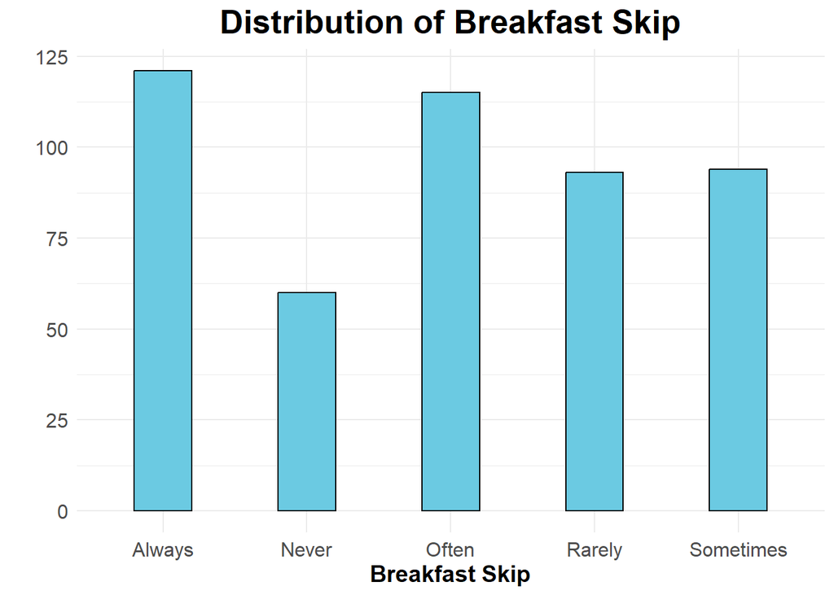

```r
ggplot(df, aes(x = BreakfastSkip, fill = SleeplessNightsInAWeek)) +
  geom_bar(color = "black", fill = "#6BCAE2", width = 0.4) +
  labs(title = "Distribution of Breakfast Skip", x = "Breakfast Skip", y = "") +
  theme_minimal()+theme(
    plot.title = element_text(size = 20, face = "bold", hjust = 0.5),
    axis.title.x = element_text(size = 14, face = "bold"),
    axis.title.y = element_text(size = 14, face = "bold"),
    axis.text = element_text(size = 12)
  )
```

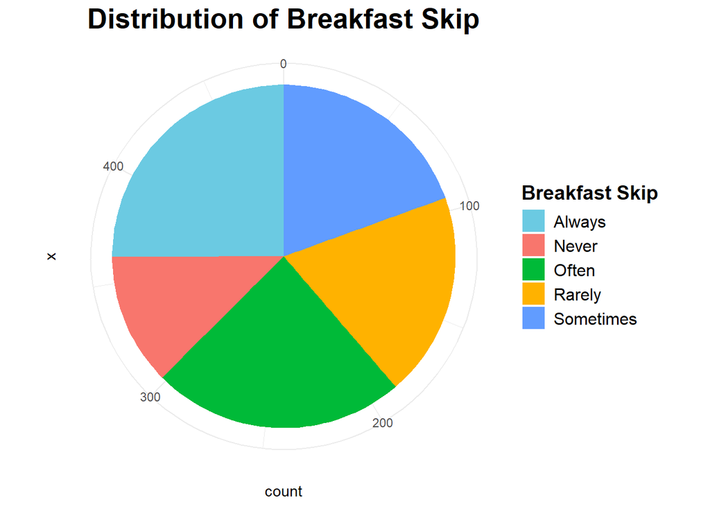

```r
ggplot(df, aes(x = "", fill = factor(BreakfastSkip))) +
  geom_bar(width = 1) +
  coord_polar("y") +
  labs(title = "Distribution of Breakfast Skip", fill = "Breakfast Skip")+
  theme_minimal() +
  theme(
    plot.title = element_text(size = 20, face = "bold", hjust = 0.5),
    legend.title = element_text(size = 14, face = "bold"),
    legend.text = element_text(size = 12)
  ) +
  scale_fill_manual(values = c("#6BCAE2", "#F8766D", "#00BA38", "#FFB200","#619CFF"))
```

**Count of Unique Values in Dinner Time Column**

```r
count14 <- table(df$DinnerTime, df$SleeplessNightsInAWeek)
count14
```

```
##
##                 0   1   2   3   4   5   6   7
##   19:00-20:00  34   7   4   0   0   0   0   1
##   20:00-21:00 174  49  21   8   1   1   2   1
##   21:00-22:00  70  32  13   1   5   5   0   1
##   22:00-23:00  13   9   6   2   1   0   1   1
##   23:00+        6   2   2   1   1   1   0   7
```

**Distribution of Dinner Time**

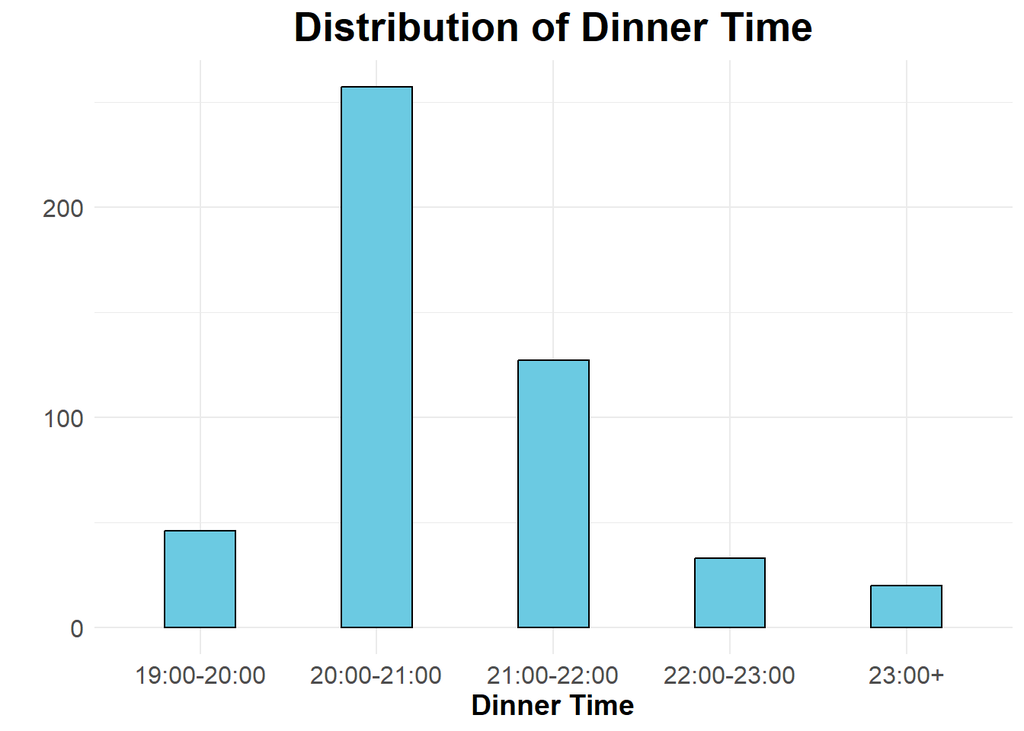

```r
ggplot(df, aes(x = DinnerTime, fill = SleeplessNightsInAWeek)) +
  geom_bar(color = "black", fill = "#6BCAE2", width = 0.4) +
  labs(title = "Distribution of Dinner Time", x = "Dinner Time", y = "") +
  theme_minimal()+theme(
    plot.title = element_text(size = 20, face = "bold", hjust = 0.5),
    axis.title.x = element_text(size = 14, face = "bold"),
    axis.title.y = element_text(size = 14, face = "bold"),
    axis.text = element_text(size = 12)
  )
```

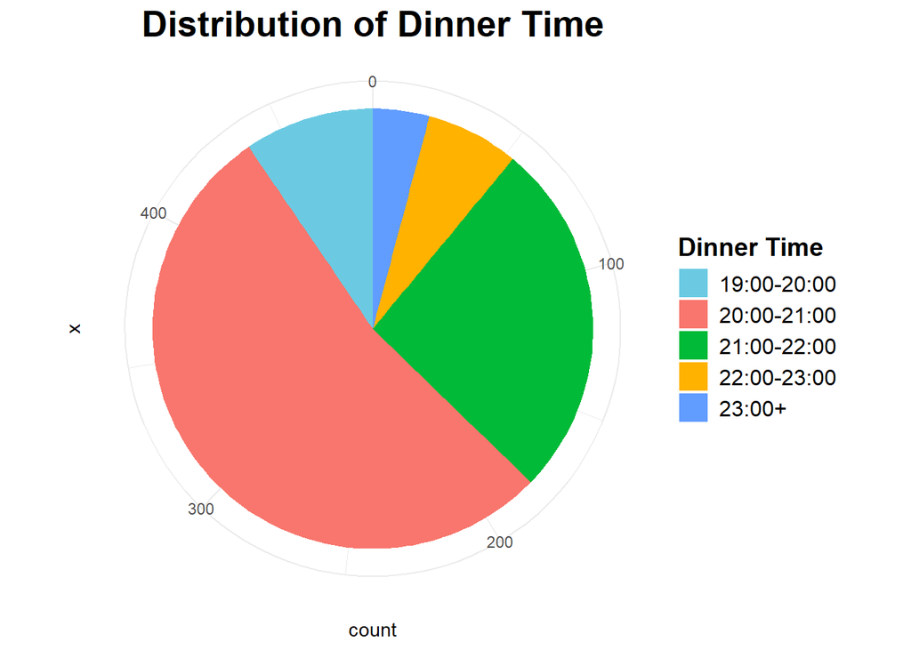

```r
ggplot(df, aes(x = "", fill = factor(DinnerTime))) +
  geom_bar(width = 1) +
  coord_polar("y") +
  labs(title = "Distribution of Dinner Time", fill = "Dinner Time")+
  theme_minimal() +
  theme(
    plot.title = element_text(size = 20, face = "bold", hjust = 0.5),
    legend.title = element_text(size = 14, face = "bold"),
    legend.text = element_text(size = 12)
  ) +
  scale_fill_manual(values = c("#6BCAE2", "#F8766D", "#00BA38", "#FFB200","#619CFF"))
```

**Identifying Outliers**